# Action Report: WeRateDogs Insights

WeRateDogs is a Twitter account that rates people's dogs with a humorous comment about the dog. I extracted insights from the WeRateDogs data by asking the following questions:

**1. Which dog has the most number of fans?**

**2. What is the rank of dog stages by most ratings?**

**3. Is there a correlation between some dog breeds and people interaction on Twitter?**

## Which Dog Has The Most Number of Fans?

This question was answered by analyzing the number of retweets and favorites *(or favorites)* each dog.  
The results are shown here:

The most three dogs have fans are..

- **Unknown** with retweet count of **79515** and favorite count of **131075**
- **Stephan** with retweet count of **56625** and favorite count of **107015**
- **Unknown** with retweet count of **52360** and favorite count of **75163**

The **Unknown** here indicates that the data has missing dog names.

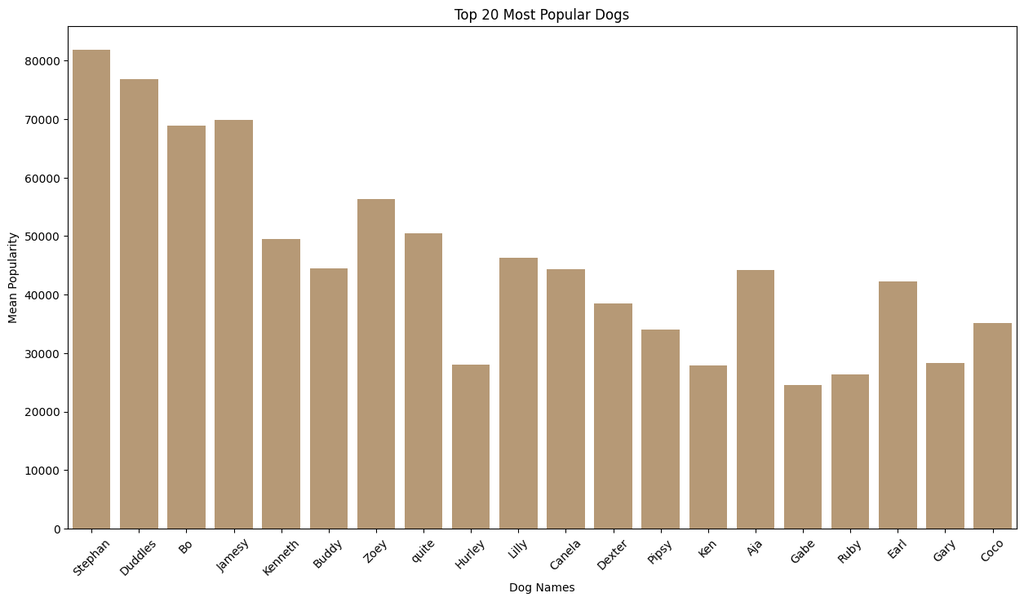

## What is the Rank of Dog Stages by Most Ratings?

This question answered by getting the average rating for each dog stage and comparing between them to know which dog stages people like more.  
The visualization below shows the average rating for each dog stage.

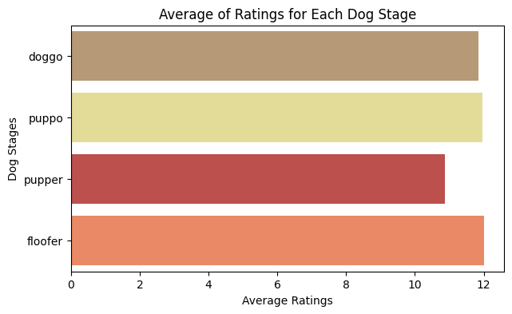

This visualization shows that the highest average rating is for **puppo** and **floofer** with an average rating of about **12** and the lowest average rating is for **pupper** with an average rating of about **11**.  
The average rating of all dog stages is above **10** and that was expected since *WeRateDogs* Twitter account is known for giving dogs a rating above **10**.  
All dog stages have nearly the same average rating with a small difference between them.

## Is There a Correlation Between Some Dog Breeds and People Interaction on Twitter?

This question will be answered by getting the average **retweets and favorites** for each **dog breed** and comparing between them to know which dog breeds people like more.  
The visualization below displays this correlation well.

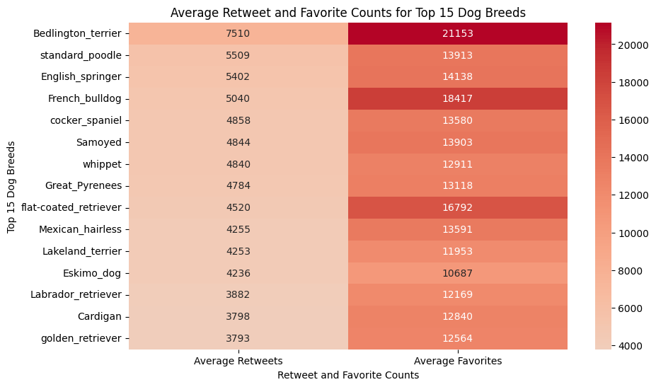

The project has provided valuable insights into the *WeRateDogs* dataset and demonstrated the importance of data wrangling in the data analysis process. The cleaned dataset is now ready for further analysis and exploration. There are many other insights that can be extracted from the data by combining other variables and analyzing them together. The analysis above is just a sample of the insights that can be extracted from the WeRateDogs data.